# DATA 608 - Module 1

Mohamed Thasleem Kalikul Zaman

Feb 9,2020

**Principles of Data Visualization and Introduction to ggplot2**

I have provided you with data about the 5,000 fastest growing companies in the US, as compiled by Inc. magazine. lets read this in:

```r
inc <- read.csv("https://raw.githubusercontent.com/charleyferrari/CUNY_DATA_608/master/module1/Data/inc5000_data.csv", header= TRUE)
```

And lets preview this data:

```r
library(knitr)
library(kableExtra)
#head(inc)
kable(head(inc)) %>%
  kable_styling(bootstrap_options = c("striped", "hover", "condensed", "responsive")) %>%
  row_spec(0, bold = T, color = "white", background = "#ea7872")
```

| Rank | Name | Growth_Rate | Revenue | Industry | Employees | City | State |
| --- | --- | --- | --- | --- | --- | --- | --- |
| 1 | Fuhu | 421.48 | 1.179e+08 | Consumer Products & Services | 104 | El Segundo | CA |
| 2 | FederalConference.com | 248.31 | 4.960e+07 | Government Services | 51 | Dumfries | VA |
| 3 | The HCI Group | 245.45 | 2.550e+07 | Health | 132 | Jacksonville | FL |
| 4 | Bridger | 233.08 | 1.900e+09 | Energy | 50 | Addison | TX |
| 5 | DataXu | 213.37 | 8.700e+07 | Advertising & Marketing | 220 | Boston | MA |
| 6 | MileStone Community Builders | 179.38 | 4.570e+07 | Real Estate | 63 | Austin | TX |

```r
summary(inc)
```

```
##       Rank                          Name       Growth_Rate
##  Min.   :   1   (Add)ventures         :   1   Min.   :  0.340
##  1st Qu.:1252   @Properties           :   1   1st Qu.:  0.770
##  Median :2502   1-Stop Translation USA:   1   Median :  1.420
##  Mean   :2502   110 Consulting        :   1   Mean   :  4.612
##  3rd Qu.:3751   11thStreetCoffee.com  :   1   3rd Qu.:  3.290
##  Max.   :5000   123 Exteriors         :   1   Max.   :421.480
##                 (Other)               :4995
##     Revenue                                  Industry      Employees
##  Min.   :2.000e+06   IT Services                 : 733   Min.   :    1.0
##  1st Qu.:5.100e+06   Business Products & Services: 482   1st Qu.:   25.0
##  Median :1.090e+07   Advertising & Marketing     : 471   Median :   53.0
##  Mean   :4.822e+07   Health                      : 355   Mean   :  232.7
##  3rd Qu.:2.860e+07   Software                    : 342   3rd Qu.:  132.0
##  Max.   :1.010e+10   Financial Services          : 260   Max.   :66803.0
##                      (Other)                     :2358   NA's   :12
##             City          State
##  New York     : 160   CA     : 701
##  Chicago      :  90   TX     : 387
##  Austin       :  88   NY     : 311
##  Houston      :  76   VA     : 283
##  San Francisco:  75   FL     : 282
##  Atlanta      :  74   IL     : 273
##  (Other)      :4438   (Other):2764
```

Think a bit on what these summaries mean. Use the space below to add some more relevant non-visual exploratory information you think helps you understand this data:

**To get better understanding of data, geting some additional stats like sd, trimed, se can help.**

```r
# Insert your code here, create more chunks as necessary
library(psych)
describe(inc)
```

```
##             vars    n        mean           sd    median     trimmed
## Rank           1 5001     2501.64      1443.51 2.502e+03     2501.73
## Name*          2 5001     2501.00      1443.81 2.501e+03     2501.00
## Growth_Rate    3 5001        4.61        14.12 1.420e+00        2.14
## Revenue        4 5001 48222535.49 240542281.14 1.090e+07 17334966.26
## Industry*      5 5001       12.10         7.33 1.300e+01       12.05
## Employees      6 4989      232.72      1353.13 5.300e+01       81.78
## City*          7 5001      732.00       441.12 7.610e+02      731.74
## State*         8 5001       24.80        15.64 2.300e+01       24.44
##                     mad     min        max      range  skew kurtosis
## Rank            1853.25 1.0e+00 5.0000e+03 4.9990e+03  0.00    -1.20
## Name*           1853.25 1.0e+00 5.0010e+03 5.0000e+03  0.00    -1.20
## Growth_Rate        1.22 3.4e-01 4.2148e+02 4.2114e+02 12.55   242.34
## Revenue     10674720.00 2.0e+06 1.0100e+10 1.0098e+10 22.17   722.66
## Industry*          8.90 1.0e+00 2.5000e+01 2.4000e+01 -0.10    -1.18
## Employees         53.37 1.0e+00 6.6803e+04 6.6802e+04 29.81  1268.67
## City*            604.90 1.0e+00 1.5190e+03 1.5180e+03 -0.04    -1.26
## State*            19.27 1.0e+00 5.2000e+01 5.1000e+01  0.12    -1.46
##                     se
## Rank             20.41
## Name*            20.42
## Growth_Rate       0.20
## Revenue     3401441.44
## Industry*         0.10
## Employees        19.16
## City*             6.24
## State*            0.22
```

## Question 1

Create a graph that shows the distribution of companies in the dataset by State (ie how many are in each state). There are a lot of States, so consider which axis you should use. This visualization is ultimately going to be consumed on a ‘portrait’ oriented screen (ie taller than wide), which should further guide your layout choices.

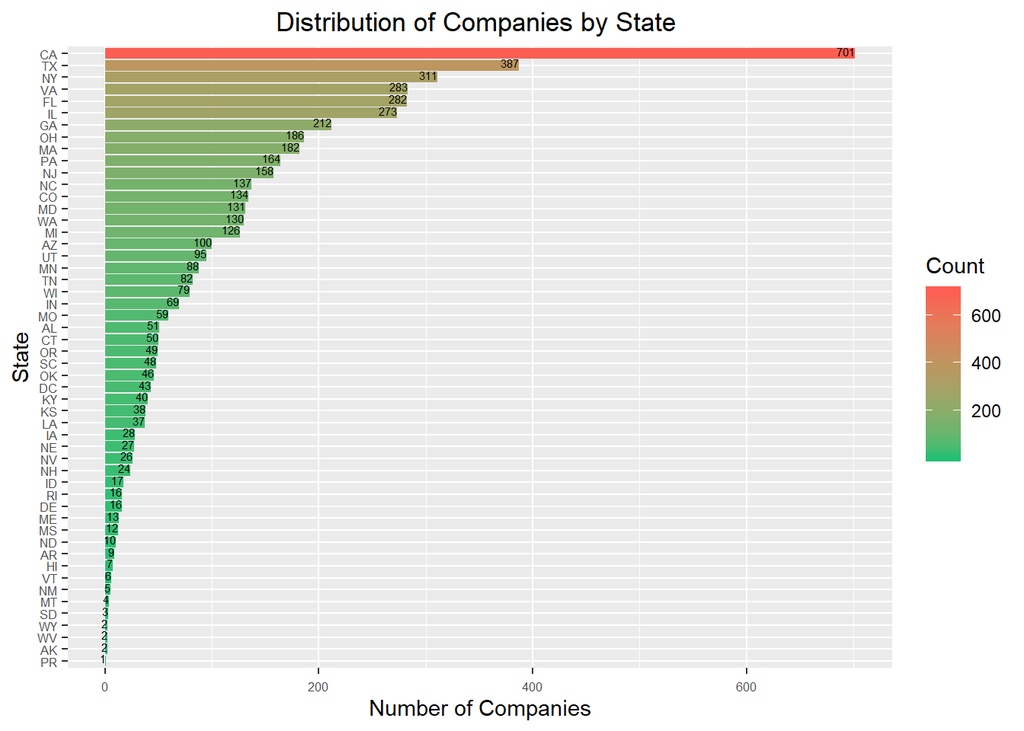

```r
library(tidyverse)
#dataset
state_df <- inc %>% group_by(State) %>% summarize(Count = n()) %>% arrange(desc(Count))
#state_df

#plotting
g1 <- ggplot(state_df, aes(x=reorder(State,Count),y=Count, fill=Count)) + scale_fill_gradient(low = "#21bf73", high = "#fd5e53")+ coord_flip() +
  geom_bar(stat="identity") +
  geom_text(aes(label=round(Count, digits=2)), vjust=0.2, size=2, position=position_dodge(width = 1), hjust=1) +
  theme(axis.text.x=element_text(size=6, vjust=0.5)) + theme(axis.text.y=element_text(size=6, vjust=0.5)) +
  labs( x="State", y="Number of Companies") + ggtitle("Distribution of Companies by State ") +
  theme(plot.title = element_text(hjust = 0.5))
g1
```

## Quesiton 2

Lets dig in on the state with the 3rd most companies in the data set. Imagine you work for the state and are interested in how many people are employed by companies in different industries. Create a plot that shows the average and/or median employment by industry for companies in this state (only use cases with full data, use R’s `complete.cases()` function.) In addition to this, your graph should show how variable the ranges are, and you should deal with outliers.

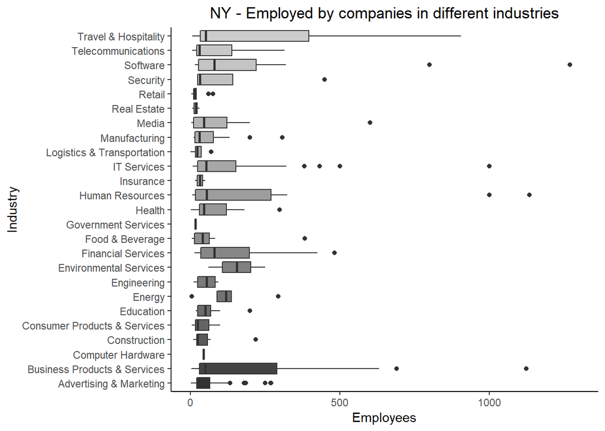

```r
#complete.cases
inc_cc <- inc[complete.cases(inc),]

#filter NY
inc_cc_ny <- inc_cc %>% filter(State == "NY")

#plotting
g2 <- ggplot(inc_cc_ny, aes(x=inc_cc_ny$Industry, y=inc_cc_ny$Employees, fill=inc_cc_ny$Industry )) + coord_flip() +
  geom_boxplot(na.rm = TRUE) + ylim(0,1300) + theme(axis.text.x = element_text(angle = 90, hjust = 1)) +
  scale_fill_grey() + theme_classic() + theme(legend.position ="none") + labs( x="Industry", y="Employees") +
  ggtitle("NY - Employed by companies in different industries") + theme(plot.title = element_text(hjust = 0.5))
g2
```

## Question 3

Now imagine you work for an investor and want to see which industries generate the most revenue per employee. Create a chart that makes this information clear. Once again, the distribution per industry should be shown.

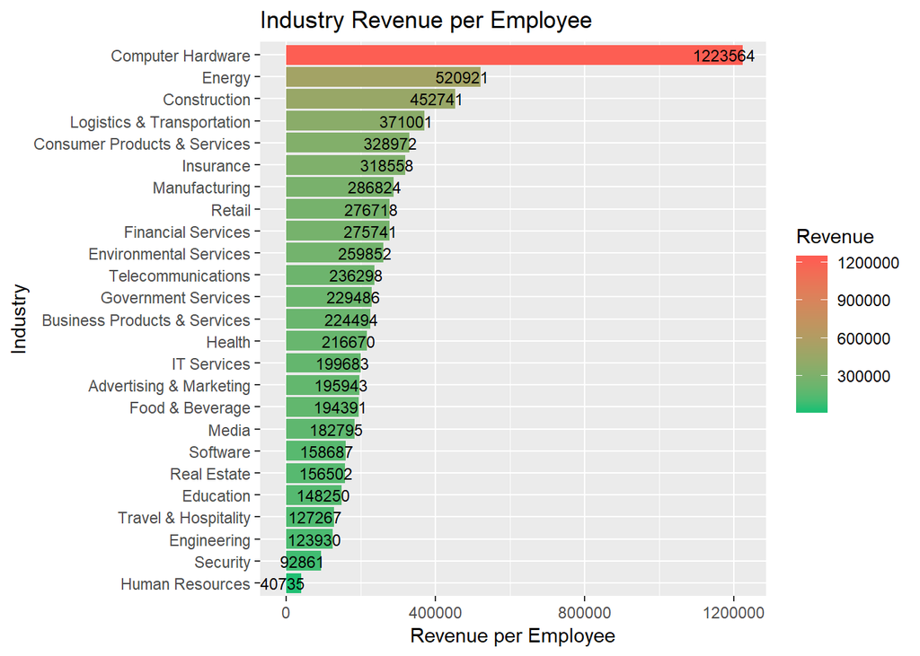

```r
#complete.cases
inc <- inc[complete.cases(inc),]

#subsetting the data
industry_emp <- inc %>%
  group_by(Industry) %>%
  summarise(Revenue=sum(Revenue), Employees=sum(Employees)) %>%
  mutate(Revenue_per_Employee = Revenue/Employees)

#plotting
g3 <- ggplot(industry_emp, aes(x=reorder(Industry, Revenue_per_Employee), y=Revenue_per_Employee, fill=Revenue_per_Employee)) +
  geom_bar(stat='identity') + scale_fill_gradient(low = "#21bf73", high = "#fd5e53") +
  labs(title="Industry Revenue per Employee",x='Industry', y='Revenue per Employee', fill="Revenue") +
  geom_text(aes(y=Revenue_per_Employee-50000, label=round(Revenue_per_Employee,0)), color='black', size=3) +
  coord_flip()
g3
```